# Palgen cytoeffect PLMM

Lucy Quirant

4/23/2019

#Goal of document: Apply the Poisson Log-Normal Mixed Model of the cytoeffect package to the Palgen HIV dataset (2019).

#cytoeffect - 3 parts: A) logistic linear mixed model (LLMM); B) poisson log-normal mixed model (PLMM); This is part B.

# Prerequisites

###Parse input parameters.

```r
ncells = 2000 #later can set to Inf (infinite)
seed = 0xdada
ncores = parallel::detectCores()
cytof_data = "se_palgen2019vaccine.Rdata"
prefit_PLMM = paste0("cytoeffect_plmm_ncells_",ncells,".Rdata")
prefit_PLMM
```

```
## [1] "cytoeffect_plmm_ncells_2000.Rdata"
```

###Install packages.

```r
pkgs_needed = c("devtools","tidyverse","magrittr","SummarizedExperiment",
                "ggthemes","cowplot","RColorBrewer","broom","hexbin",
                "intergraph","igraph","ggnetwork","ggcorrplot","MASS",
                "parallel","dplyr")
letsinstall = setdiff(pkgs_needed, installed.packages())
if (length(letsinstall) > 0) {
  BiocManager::install(letsinstall)
}
devtools::install_github("ChristofSeiler/cytoeffect")
```

###Load packages.

```r
library("cytoeffect")
library("tidyverse")
library("magrittr")
library("SummarizedExperiment")
library("ggthemes")
library("cowplot")
library("RColorBrewer")
library("broom")
library("intergraph")
library("igraph")
library("ggnetwork")
library("ggcorrplot")
library("MASS")
library("parallel")
library("dplyr")
theme_set(theme_few())
```

# Load Data

###Load `SummarizedExperiment` object from CytoGLMM workflow.

```r
rdata_filenames = c(cytof_data, prefit_PLMM)
load(cytof_data)
exprs = assay(se_palgen2019vaccine)
sample_info = rowData(se_palgen2019vaccine)
sample_info_names = names(sample_info)
df_samples = cbind(as.data.frame(exprs), as.data.frame(sample_info))
df_samples %<>% as.tibble
protein_names = colData(se_palgen2019vaccine) %>%
  as.data.frame %>%
  dplyr::filter(type != "unused") %>%
  .$protein_name
```

# Fit Model

###Tally cell count.

```r
df_samples %>% group_by(term,donor) %>% tally %>% arrange(n)
```

```
## # A tibble: 8 x 3
## # Groups:   term [2]
##   term       donor      n
##   <fct>      <chr>  <int>
## 1 Post-prime BD620  93624
## 2 Post-prime BB078 163789
## 3 Post-boost BD620 171421
## 4 Post-prime BC641 172985
## 5 Post-boost BB078 206027
## 6 Post-prime BB231 228105
## 7 Post-boost BC641 264225
## 8 Post-boost BB231 330010
```

```r
df_samples %>% group_by(term,donor) %>% tally %>% arrange(desc(n))
```

```
## # A tibble: 8 x 3
## # Groups:   term [2]
##   term       donor      n
##   <fct>      <chr>  <int>
## 1 Post-boost BB231 330010
## 2 Post-boost BC641 264225
## 3 Post-prime BB231 228105
## 4 Post-boost BB078 206027
## 5 Post-prime BC641 172985
## 6 Post-boost BD620 171421
## 7 Post-prime BB078 163789
## 8 Post-prime BD620  93624
```

###Subsample cells to a maximum number of cells per donor.

```r
if(nrow(df_samples) > ncells) {
  print(paste("subsampled to",ncells,"per donor"))
  set.seed(seed)
  # subsample depending on max cell count
  df_count = df_samples %>% group_by(donor) %>% tally() %>%
    mutate(nnew = ifelse(n > ncells,ncells,n))
  # create table with a data frame in one column
  df_nested = df_samples %>% group_by(donor) %>% nest() %>%
    left_join(df_count,by = "donor")
  # subsample per donor
  df_samples = df_nested %>%
    mutate(samp = map2(data, nnew, sample_n)) %>%
    dplyr::select(donor, samp) %>%
    unnest()
} else {
  print("no subsampling done")
}
```

```
## [1] "subsampled to 2000 per donor"
```

###Tally cell count.

```r
df_samples %>% group_by(term,donor) %>% tally %>%
  arrange(n)
```

```
## # A tibble: 8 x 3
## # Groups:   term [2]
##   term       donor     n
##   <fct>      <chr> <int>
## 1 Post-prime BD620   722
## 2 Post-prime BC641   780
## 3 Post-prime BB231   815
## 4 Post-prime BB078   887
## 5 Post-boost BB078  1113
## 6 Post-boost BB231  1185
## 7 Post-boost BC641  1220
## 8 Post-boost BD620  1278
```

```r
df_samples %>% group_by(term,donor) %>% tally %>%
  arrange(desc(n))
```

```
## # A tibble: 8 x 3
## # Groups:   term [2]
##   term       donor     n
##   <fct>      <chr> <int>
## 1 Post-boost BD620  1278
## 2 Post-boost BC641  1220
## 3 Post-boost BB231  1185
## 4 Post-boost BB078  1113
## 5 Post-prime BB078   887
## 6 Post-prime BB231   815
## 7 Post-prime BC641   780
## 8 Post-prime BD620   722
```

## HMC Sampling

Sample from posterior distribution (initialization details in paper).

```r
df_samples$term %<>% factor(levels = c("Post-prime",
                                              "Post-boost"))
```

```r
if(file.exists(prefit_PLMM)) {
  load(file = prefit_PLMM)
} else {
  obj = cytoeffect::poisson_lognormal(df_samples, protein_names,
                                      condition = "term", group = "donor",
                                      iter = 325, warmup = 200,
                                      num_chains = ncores)
  save(obj,file = prefit_PLMM)
}
```

## HMC Diagnostics

Postprocessing of posterior samples. Traceplot of posterior samples.

ERROR - doesn’t look right - maybe just too many for space? 7/05 NOTE: successful poisson sampling; 62 post-sampling graphs, none show the usual colours, just numbers on top of each other –> too many graphs for the space, when subset shows correctly

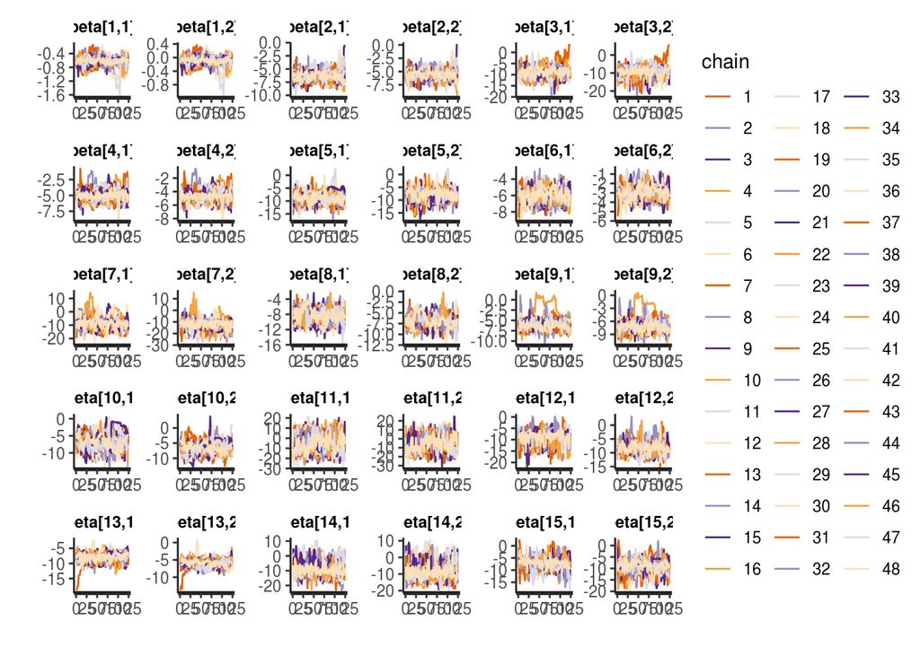

```r
rstan::traceplot(obj$fit_mcmc, inc_warmup = FALSE, pars = c("beta[1,1]", "beta[1,2]", "beta[2,1]", "beta[2,2]", "beta[3,1]", "beta[3,2]", "beta[4,1]", "beta[4,2]", "beta[5,1]", "beta[5,2]", "beta[6,1]", "beta[6,2]", "beta[7,1]", "beta[7,2]", "beta[8,1]", "beta[8,2]", "beta[9,1]", "beta[9,2]", "beta[10,1]", "beta[10,2]", "beta[11,1]", "beta[11,2]", "beta[12,1]", "beta[12,2]", "beta[13,1]", "beta[13,2]", "beta[14,1]", "beta[14,2]", "beta[15,1]", "beta[15,2]"))
```

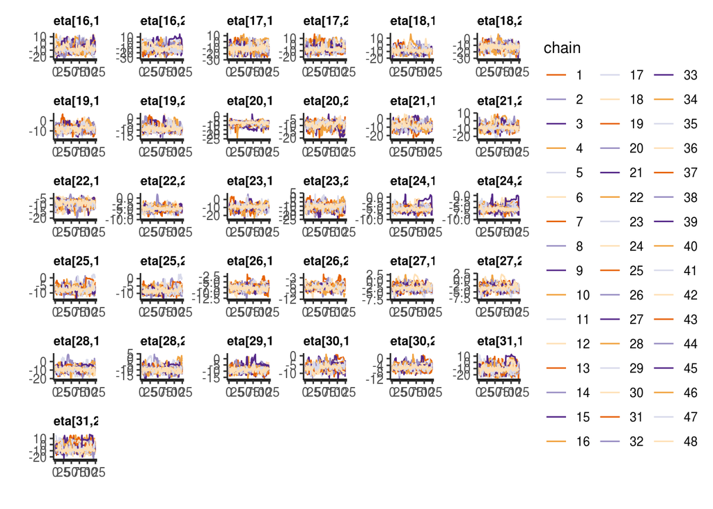

```r
rstan::traceplot(obj$fit_mcmc, inc_warmup = FALSE, pars = c("beta[16,1]", "beta[16,2]", "beta[17,1]", "beta[17,2]", "beta[18,1]", "beta[18,2]", "beta[19,1]", "beta[19,2]", "beta[20,1]", "beta[20,2]", "beta[21,1]", "beta[21,2]", "beta[22,1]", "beta[22,2]", "beta[23,1]", "beta[23,2]", "beta[24,1]", "beta[24,2]", "beta[25,1]", "beta[25,2]", "beta[26,1]", "beta[26,2]", "beta[27,1]", "beta[27,2]", "beta[28,1]", "beta[28,2]", "beta[29,1]", "beta[29,1]", "beta[30,1]", "beta[30,2]", "beta[31,1]", "beta[31,2]"))
```

Some more MCMC diagnostics. According to empirically findings, Rhat > 1.1 is usually indicative of problems in the fit.

```r
pars = c("beta",
         "sigma","sigma_term","sigma_donor",
         "Cor","Cor_term","Cor_donor", "b_donor")
#b_donor seems to be newly added
tb = summary(obj$fit_mcmc,
             pars = pars)$summary %>%
  as.tibble(rownames = "pars", .before = 1) %>%
  dplyr::select(pars, n_eff, Rhat)
tb %<>% na.omit() # Stan fills upper triangle with zeros
tb %>% arrange(n_eff)
```

```
## # A tibble: 3,132 x 3
##    pars           n_eff  Rhat
##    <chr>          <dbl> <dbl>
##  1 Cor_term[1,4]   31.0  3.11
##  2 Cor_term[4,1]   31.0  3.11
##  3 Cor_term[1,24]  31.5  2.97
##  4 Cor_term[24,1]  31.5  2.97
##  5 Cor_term[1,2]   31.6  2.93
##  6 Cor_term[2,1]   31.6  2.93
##  7 Cor_term[1,26]  31.7  2.89
##  8 Cor_term[26,1]  31.7  2.89
##  9 Cor_term[1,25]  37.1  2.06
## 10 Cor_term[25,1]  37.1  2.06
## # … with 3,122 more rows
```

```r
tb %>% arrange(desc(Rhat))
```

```
## # A tibble: 3,132 x 3
##    pars           n_eff  Rhat
##    <chr>          <dbl> <dbl>
##  1 Cor_term[1,4]   31.0  3.11
##  2 Cor_term[4,1]   31.0  3.11
##  3 Cor_term[1,24]  31.5  2.97
##  4 Cor_term[24,1]  31.5  2.97
##  5 Cor_term[1,2]   31.6  2.93
##  6 Cor_term[2,1]   31.6  2.93
##  7 Cor_term[1,26]  31.7  2.89
##  8 Cor_term[26,1]  31.7  2.89
##  9 Cor_term[1,25]  37.1  2.06
## 10 Cor_term[25,1]  37.1  2.06
## # … with 3,122 more rows
```

```r
tb %>% summarize(min = min(n_eff), max = max(n_eff))
```

```
## # A tibble: 1 x 2
##     min   max
##   <dbl> <dbl>
## 1  31.0 4831.
```

```r
tb %>% summarize(min = min(Rhat), max = max(Rhat))
```

```
## # A tibble: 1 x 2
##     min   max
##   <dbl> <dbl>
## 1 0.992  3.11
```